# AdFraudClick_Detection

Madhuri Kalani

April 17, 2018

## Ad_Fraud_Clicks_Detection

The objective is to predict whether a user will download an application after clicking a mobile advertisement.

Looking at the data it looks like a classification problem that outputs two classes. The training data and test data consists of 184 million and 1.8 million rows respectively. Each row of training data contains a click record, with the following features:

1. ip: ip address of click.
2. app: app id for marketing.
3. device: device type id of user mobile phone (e.g., iphone 6 plus, huawei mate 7, etc.)
4. os: os version id of user mobile phone
5. channel: channel id of mobile ad publisher
6. click_time: timestamp of click (UTC)
7. attributed_time: if user download the app for after clicking an ad, this is the time of the app download
8. is_attributed: the target that is to be predicted, indicating the app was downloaded (1= app downloaded, 0= not downloaded)

Please note that ip, app, device, os, and channel are encoded.

The test data is similar, with the following differences: 1. click_id: reference for making predictions 2. is_attributed: not included

### Step 1: Loading the Project and training data.

```
## [1] "C:/Users/akash/Documents/Madhuri stuff/Data_Science_Intro_R/Ad_Fraud_Detection"
```

```
##       ip app device os channel          click_time attributed_time
## 1  87540  12      1 13     497 2017-11-07 09:30:38
## 2 105560  25      1 17     259 2017-11-07 13:40:27
## 3 101424  12      1 19     212 2017-11-07 18:05:24
## 4  94584  13      1 13     477 2017-11-07 04:58:08
## 5  68413  12      1  1     178 2017-11-09 09:00:09
## 6  93663   3      1 17     115 2017-11-09 01:22:13
##   is_attributed
## 1             0
## 2             0
## 3             0
## 4             0
## 5             0
## 6             0
```

### Step 2: The training data contains 8 variables as shown above. I will be adding few more columns to the training data.

#### Showing Structure and Summary of the training dataset

```
## 'data.frame':    100000 obs. of  11 variables:
##  $ ip             : int  87540 105560 101424 94584 68413 93663 17059 121505 192967 143636 ...
##  $ app            : int  12 25 12 13 12 3 1 9 2 3 ...
##  $ device         : int  1 1 1 1 1 1 1 1 2 1 ...
##  $ os             : int  13 17 19 13 1 17 17 25 22 19 ...
##  $ channel        : int  497 259 212 477 178 115 135 442 364 135 ...
##  $ click_time     : POSIXct, format: "2017-11-07 09:30:38" "2017-11-07 13:40:27" ...
##  $ attributed_time: Factor w/ 228 levels "","2017-11-06 17:19:04",..: 1 1 1 1 1 1 1 1 1 1 ...
##  $ is_attributed  : int  0 0 0 0 0 0 0 0 0 0 ...
##  $ click_hour     : int  9 13 18 4 9 1 1 10 9 12 ...
##  $ click_day      : chr  "Tuesday" "Tuesday" "Tuesday" "Tuesday" ...
##  $ click_month    : num  11 11 11 11 11 11 11 11 11 11 ...
```

```
##        ip              app             device              os
##  Min.   :     9   Min.   :  1.00   Min.   :   0.00   Min.   :  0.00
##  1st Qu.: 40552   1st Qu.:  3.00   1st Qu.:   1.00   1st Qu.: 13.00
##  Median : 79827   Median : 12.00   Median :   1.00   Median : 18.00
##  Mean   : 91256   Mean   : 12.05   Mean   :  21.77   Mean   : 22.82
##  3rd Qu.:118252   3rd Qu.: 15.00   3rd Qu.:   1.00   3rd Qu.: 19.00
##  Max.   :364757   Max.   :551.00   Max.   :3867.00   Max.   :866.00
##
##     channel        click_time                             attributed_time
##  Min.   :  3.0   Min.   :2017-11-06 16:00:00                      :99773
##  1st Qu.:145.0   1st Qu.:2017-11-07 11:34:09   2017-11-06 17:19:04:    1
##  Median :258.0   Median :2017-11-08 07:07:50   2017-11-06 21:30:47:    1
##  Mean   :268.8   Mean   :2017-11-08 06:29:52   2017-11-06 23:16:28:    1
##  3rd Qu.:379.0   3rd Qu.:2017-11-09 02:06:01   2017-11-06 23:58:31:    1
##  Max.   :498.0   Max.   :2017-11-09 15:59:51   2017-11-07 00:15:11:    1
##                                                (Other)            :  222
##  is_attributed       click_hour      click_day          click_month
##  Min.   :0.00000   Min.   : 0.000   Length:100000      Min.   :11
##  1st Qu.:0.00000   1st Qu.: 4.000   Class :character   1st Qu.:11
##  Median :0.00000   Median : 9.000   Mode  :character   Median :11
##  Mean   :0.00227   Mean   : 9.329                      Mean   :11
##  3rd Qu.:0.00000   3rd Qu.:14.000                      3rd Qu.:11
##  Max.   :1.00000   Max.   :23.000                      Max.   :11
##
```

### Step 3: Finding correlation between columns in the training data set.

```
##           ip   app device    os channel
## ip      1.00  0.01   0.00  0.00    0.01
## app     0.01  1.00   0.25  0.25   -0.03
## device  0.00  0.25   1.00  0.92   -0.04
## os      0.00  0.25   0.92  1.00   -0.03
## channel 0.01 -0.03  -0.04 -0.03    1.00
```

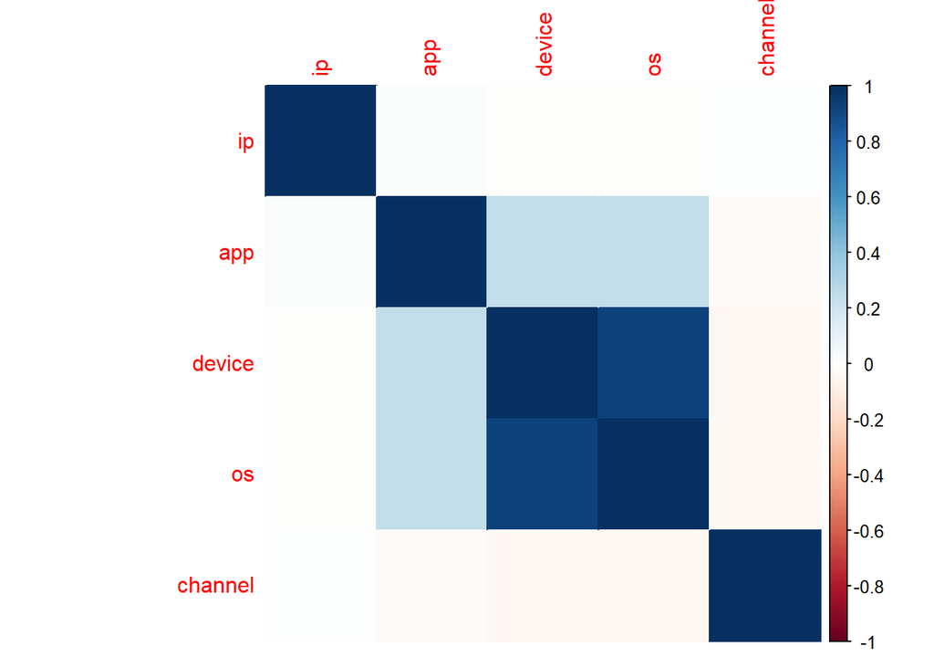

### Step 4: Building a series of histogram to see the number of times an ip address, app, os, device and channel v alues have been used

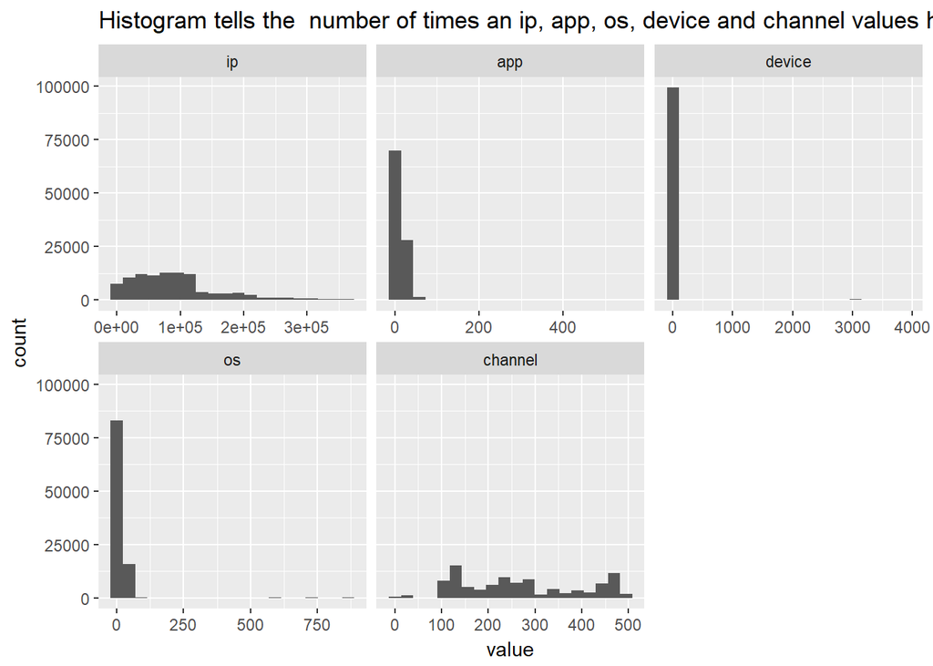

### Step 5: Coercing the dataset and making independent variables as factors

```
## 'data.frame':    100000 obs. of  11 variables:
##  $ ip             : Factor w/ 34857 levels "9","10","19",..: 15221 18449 17664 16497 11853 16301 2974 21304 28060 23645 ...
##  $ app            : Factor w/ 161 levels "1","2","3","4",..: 12 25 12 13 12 3 1 9 2 3 ...
##  $ device         : Factor w/ 100 levels "0","1","2","4",..: 2 2 2 2 2 2 2 2 3 2 ...
##  $ os             : Factor w/ 130 levels "0","1","2","3",..: 14 18 20 14 2 18 18 26 23 20 ...
##  $ channel        : Factor w/ 161 levels "3","4","5","13",..: 160 68 53 147 46 21 35 127 101 35 ...
##  $ click_time     : POSIXct, format: "2017-11-07 09:30:38" "2017-11-07 13:40:27" ...
##  $ attributed_time: Factor w/ 228 levels "","2017-11-06 17:19:04",..: 1 1 1 1 1 1 1 1 1 1 ...
##  $ is_attributed  : int  0 0 0 0 0 0 0 0 0 0 ...
##  $ click_hour     : int  9 13 18 4 9 1 1 10 9 12 ...
##  $ click_day      : chr  "Tuesday" "Tuesday" "Tuesday" "Tuesday" ...
##  $ click_month    : num  11 11 11 11 11 11 11 11 11 11 ...
```

### Step 6: Checking how many times the app has been downloaded on hourly basis

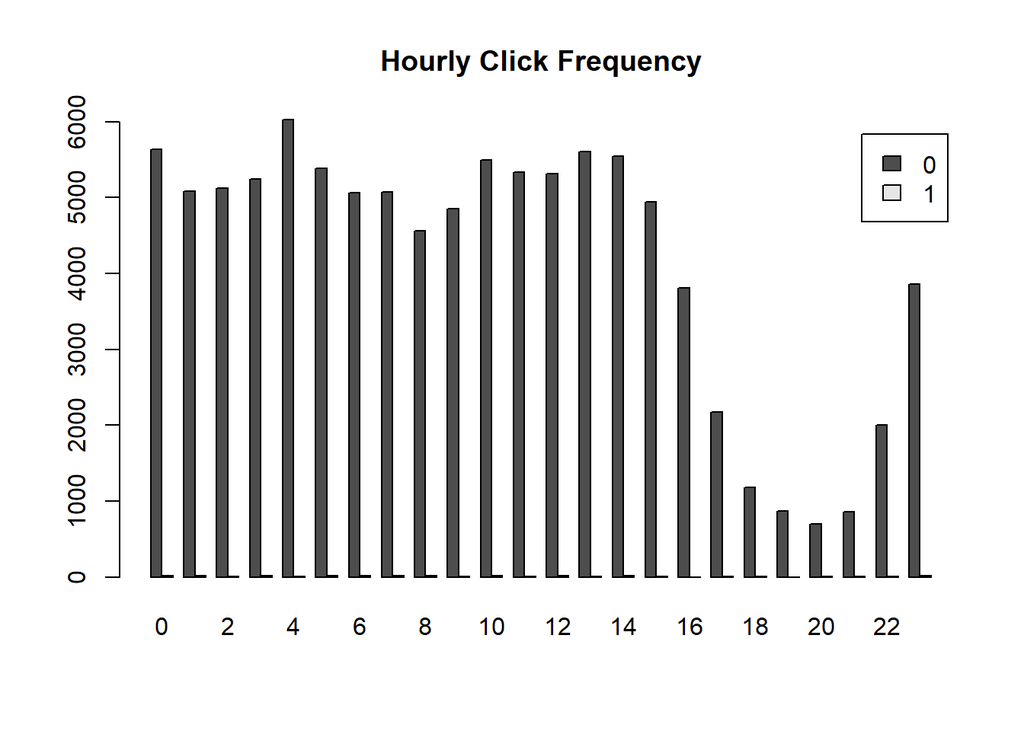

### Step 7: As my analysis continues, I will be building KNN and logistic regression models to find out the actual number of app downloads.

### I will also be trying other models before final selection and fitting the model into the test data.

##### ———————————————————————————————work in progress——————————————–